# Bio 311: Network Motif HW

Paul M. Magwene

1/31/2017

# How to complete this Homework Assignment

Feel prepare to write answers to the questions below in your program. We prefer submissions of PDFs, but if you don’t have a tool to produce PDFs on your computer you can also submit as an MS Word document.

# Network Motif HW

In coupled ODE models of gene networks, the instantaenous rate change of the amount of a gene product, $Y$, is of this form:

$$\begin{eqnarray*}
\frac{dY}{dt} = \text{rate of production} - \text{rate of decay}
\end{eqnarray*}$$

## Question Set 1 (4 pts)

We used the “logic approximation” to the Hill function to model the “rate of production” term above. The logic approximation we used has two parameters – $\beta$ and $K$.

1. Draw a graph (figure) illustrating the logic approximation for the rate of production of $Y$ as a function of the concentration of $X$ (assuming $X$ is an activator of $Y$) for the following sets of parameters ($\beta = 5$, $K = 4$), ($\beta = 5$, $K = 8$), ($\beta = 5$, $K = 12$). Use colors or line style (dashes, dots, etc) to distinguish between the three sets of parameters. Make sure to label the axes of your graph. You can sketch this graph by hand, create it in excel, etc.
2. Draw another graph illustrating the logic approximation for the rate of production of $Y$ as a function of the concentration of $X$ (again assuming $X$ is an activator of $Y$) for the following sets of parameters ($\beta = 5$, $K = 8$), ($\beta =10$, $K = 8$), ($\beta = 20$, $K = 8$). Use colors or line style (dashes, dots, etc) to distinguish between the three sets of parameters. Make sure to label the axes of your graph.

## Question Set 2 (2 pts)

To model the “rate of decay” term in our ODE model, we use a simple linear function of the form:

$$\begin{eqnarray*}
\text{rate of decay} = \alpha Y
\end{eqnarray*}$$

3. Draw a graph illustrating how the rate of decay changes as a function of the concentration of $Y$, for the $\alpha=0.1$, $\alpha=0.5$, and $\alpha=1$. Use colors or line style (dashes, dots, etc) to distinguish between the three sets of parameters. Make sure to label the axes of your graph.

## Question Set 3 (8 pts)

4. When we examine the temporal behavior from the basic differential equation give above we find that the concentration of $Y$ eventually reaches a steady state, $Y_{st}$ (see figure below). How does $Y_{st}$ relate to $\beta$ (rate of production parameter) and $\alpha$ (rate of decay parameter)?

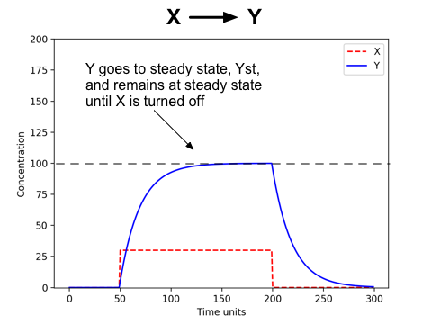

Figure showing approach and decay of Y from steady state.

5. The **response time** of a dynamical system, $T_{1/2}$is defined as the time it takes for it to go half-way between it’s initial and final value.
   - 1. How does the response time change as you vary $\beta$?
   - 2. How does the response time change as you vary $\alpha$?
6. Estimate the response time as you vary the parameter $\alpha$ and see if you can create a plot (in Python, or R, or Excel) showing the relationship between $\alpha$ and response time, for $0.01 \leq \alpha \leq 0.1$.

## Question Set 4 (8 pts)

Alon (2007) illustrates the possible dynamics of several FFLs coupled together (see figure below):

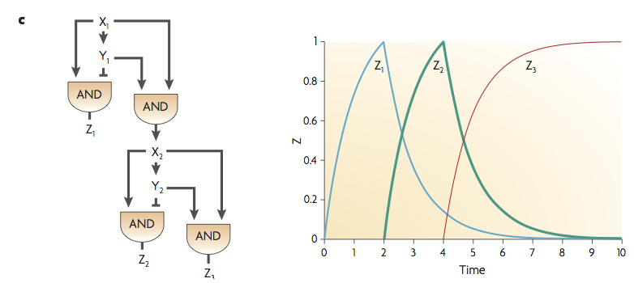

Coupled FFLs from Alon 2007, Fig 7c,d

7. (2 pts) In the network above (left subfigure), there are several coupled Feed-Forward Loops.
- What type of FFL do the genes $X_1$, $Y_1$, and $Z_1$ make?
- What type of FFL do the genes $X_1$, $Y_1$, and $X_2$ make?
8. (6 pts) Alon writes “The FFLs in this network are combined in a way that utilizes their delay and pulse-generating features to generate a temporal programme of gene expression.” This is illustrated in the figure on the right. For the questions below, assume there is a constant level of the transcription factor $X_1$.
- What features of the network topology cause $Z_1$ and $Z_2$ to turn off?
- What features of the network topology contribute to the delay between $Z_1$ turning on and $Z_2$ turning on?
- Why does gene $Z_3$ not show the same type of pulsative behavior as $Z_1$ and $Z_2$